# NL vs. D vs. UV

Anna

11/30/2022

First, set things up:

```r
rm(list=ls())
library(here)
library(tidyverse)
library(ggfortify)
```

The data have been updated to include new dates and UV data:

```r
DF <- read.csv(here("Data", "cap_color_data_final.csv"))
```

I want to observe my data to make sure all variables are included and there isn’t anything funky going on

```r
str(DF)
```

```
## 'data.frame':    706 obs. of  10 variables:
##  $ image_name         : chr  "29Sept_D1a" "29Sept_D1b" "29Sept_D1c" "29Sept_D1d" ...
##  $ L                  : int  64 63 62 66 64 77 74 66 68 80 ...
##  $ a                  : int  2 2 2 6 2 3 6 3 2 2 ...
##  $ b                  : int  -1 -1 -1 8 -3 4 7 2 1 4 ...
##  $ treatment          : chr  "D" "D" "D" "D" ...
##  $ rep                : int  1 1 1 1 1 1 1 1 1 1 ...
##  $ before_after       : chr  "after" "after" "after" "after" ...
##  $ date_collected     : chr  "9/29/22" "9/29/22" "9/29/22" "9/29/22" ...
##  $ trial_duration_days: int  7 7 7 7 7 7 7 7 7 7 ...
##  $ date_photo         : chr  "10/12/22" "10/12/22" "10/12/22" "10/12/22" ...
```

Now I want to make a new data frame to grab just the variables I am interested in

```r
Nov3 <- DF[c(468:706), c("L", "a", "b", "treatment")]
```

The “before” group is listed as “NA” for treatment, so I want to change that

```r
Nov3$treatment <- replace_na(Nov3$treatment, "control")
```

Let’s look at the structure of this new data frame now

```r
str(Nov3)
```

```
## 'data.frame':    239 obs. of  4 variables:
##  $ L        : int  59 62 62 54 53 58 52 61 58 57 ...
##  $ a        : int  19 10 8 7 8 4 10 5 9 11 ...
##  $ b        : int  12 9 5 3 3 -1 4 2 6 6 ...
##  $ treatment: chr  "control" "control" "control" "control" ...
```

I want the treatment groups to be factors

```r
Nov3$treatment <- as.factor(Nov3$treatment)
```

Let’s do a quick plot to look at the general spread of data

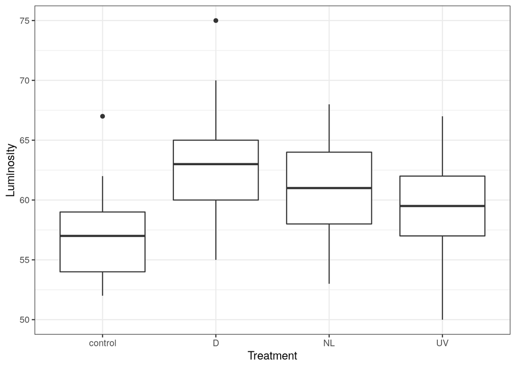

```r
ggplot(Nov3, aes(x = treatment, y = L)) +
geom_boxplot() +
xlab("Treatment") +
ylab("Luminosity") +
theme_bw()
```

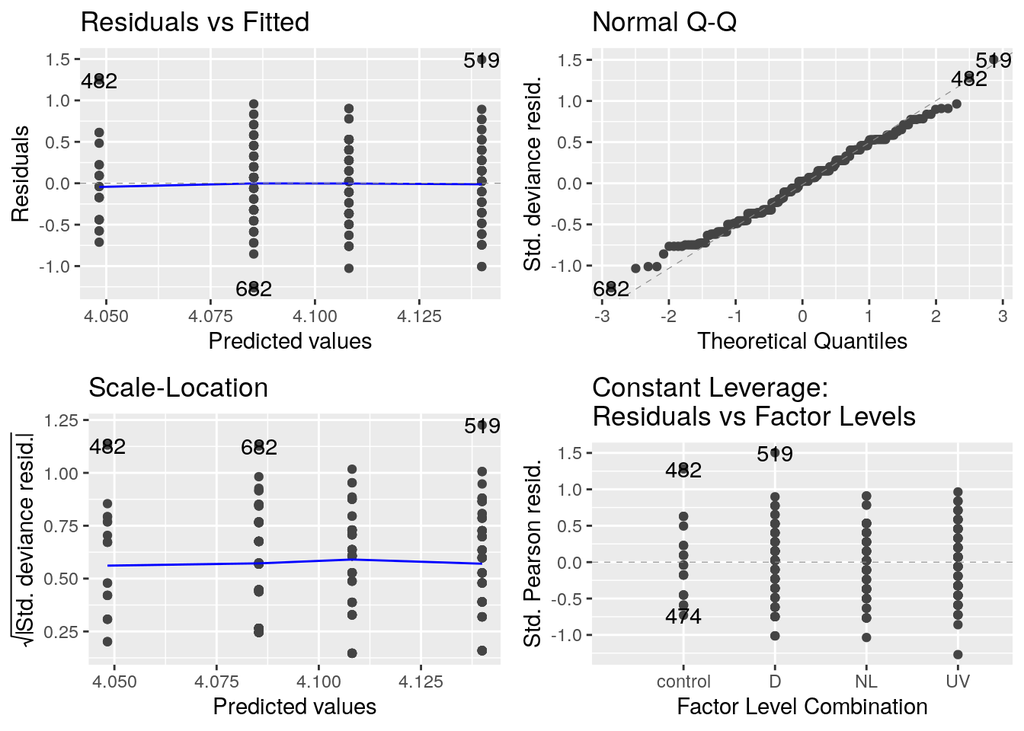

```r
model_L <- glm(L ~ treatment, data = Nov3, family = poisson)
autoplot(model_L, smooth.color = NA)
```

```r
anova(model_L, test = "Chisq")
```

```
## Analysis of Deviance Table
##
## Model: poisson, link: log
##
## Response: L
##
## Terms added sequentially (first to last)
##
##
##           Df Deviance Resid. Df Resid. Dev Pr(>Chi)
## NULL                        238     62.275
## treatment  3   11.273       235     51.002  0.01034 *
## ---
## Signif. codes:  0 '***' 0.001 '**' 0.01 '*' 0.05 '.' 0.1 ' ' 1
```

Somewhere in these treatments, there is significant difference in luminosity between treatments.

```r
summary(model_L)
```

```
##
## Call:
## glm(formula = L ~ treatment, family = poisson, data = Nov3)
##
## Deviance Residuals:
##      Min        1Q    Median        3Q       Max
## -1.26191  -0.35600   0.02136   0.32689   1.49330
##
## Coefficients:
##             Estimate Std. Error z value Pr(>|z|)
## (Intercept)  4.04830    0.02954 137.046  < 2e-16 ***
## treatmentD   0.09165    0.03294   2.783  0.00539 **
## treatmentNL  0.05984    0.03349   1.787  0.07399 .
## treatmentUV  0.03703    0.03299   1.123  0.26165
## ---
## Signif. codes:  0 '***' 0.001 '**' 0.01 '*' 0.05 '.' 0.1 ' ' 1
##
## (Dispersion parameter for poisson family taken to be 1)
##
##     Null deviance: 62.275  on 238  degrees of freedom
## Residual deviance: 51.002  on 235  degrees of freedom
## AIC: 1479.7
##
## Number of Fisher Scoring iterations: 3
```

Let’s make a nicer model:

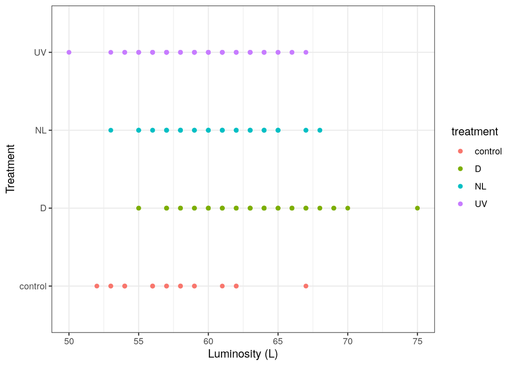

```r
ggplot(Nov3, aes(x = treatment, y = L, color = treatment)) +
  geom_point() +
  theme_bw() +
  xlab("Treatment") +
  ylab("Luminosity (L)") +
  coord_flip()
```

Perform a Tukey test to see where the significant difference lies

```r
modelL_tukey <- aov(L ~ treatment, data = Nov3)
TukeyHSD(modelL_tukey, conf.level=.95)
```

```
##   Tukey multiple comparisons of means
##     95% family-wise confidence level
##
## Fit: aov(formula = L ~ treatment, data = Nov3)
##
## $treatment
##                 diff        lwr        upr     p adj
## D-control   5.500000  3.1338765  7.8661235 0.0000000
## NL-control  3.533333  1.1334867  5.9331800 0.0010151
## UV-control  2.161538 -0.1949861  4.5180630 0.0850771
## NL-D       -1.966667 -3.5534886 -0.3798448 0.0082668
## UV-D       -3.338462 -4.8589706 -1.8179525 0.0000002
## UV-NL      -1.371795 -2.9442679  0.2006782 0.1112028
```

The copepods in the NL and D treatments became significantly more luminous. The UV copepods stayed darker and did not fade significantly from the original color.

Now, to look at the b-value

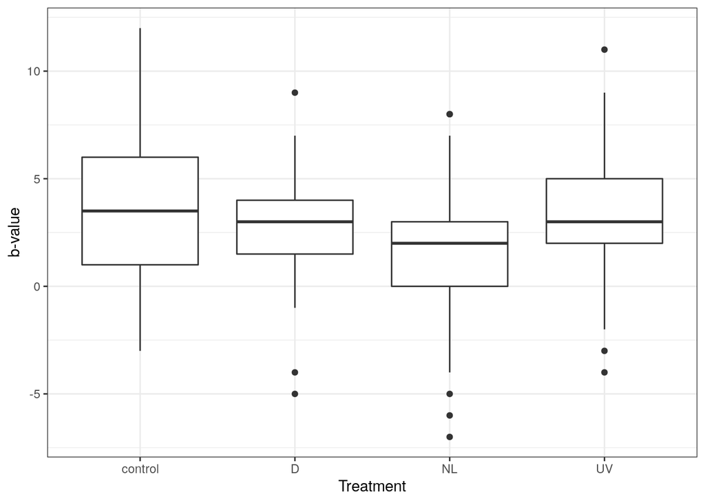

```r
ggplot(Nov3, aes(x = treatment, y = b)) +
geom_boxplot() +
xlab("Treatment") +
ylab("b-value") +
theme_bw()
```

There does not seem to be any significant difference based on this plot, but let’s run the stats

```r
model_b_tukey <- aov(b ~ treatment, data = Nov3)
TukeyHSD(model_b_tukey, conf.level=.95)
```

```
##   Tukey multiple comparisons of means
##     95% family-wise confidence level
##
## Fit: aov(formula = b ~ treatment, data = Nov3)
##
## $treatment
##                  diff        lwr        upr     p adj
## D-control  -1.1666667 -2.9970836  0.6637503 0.3531827
## NL-control -2.1878788 -4.0443838 -0.3313738 0.0135391
## UV-control -0.7333333 -2.5563246  1.0896580 0.7255913
## NL-D       -1.0212121 -2.2487667  0.2063425 0.1398029
## UV-D        0.4333333 -0.7429221  1.6095888 0.7760224
## UV-NL       1.4545455  0.2380911  2.6709999 0.0118029
```

Now to look at the a-value:

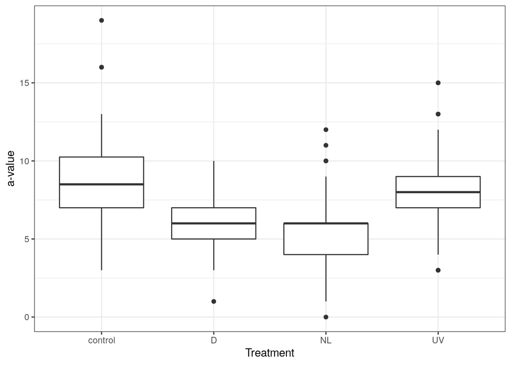

```r
ggplot(Nov3, aes(x = treatment, y = a)) +
geom_boxplot() +
xlab("Treatment") +
ylab("a-value") +
theme_bw()
```

And a Tukey test…

```r
model_a_tukey <- aov(a ~ treatment, data = Nov3)
TukeyHSD(model_a_tukey, conf.level=.95)
```

```
##   Tukey multiple comparisons of means
##     95% family-wise confidence level
##
## Fit: aov(formula = a ~ treatment, data = Nov3)
##
## $treatment
##                  diff       lwr        upr     p adj
## D-control  -3.1133333 -4.691578 -1.5350883 0.0000041
## NL-control -3.5848485 -5.185587 -1.9841096 0.0000001
## UV-control -0.9974359 -2.569278  0.5744065 0.3571741
## NL-D       -0.4715152 -1.529953  0.5869223 0.6572338
## UV-D        2.1158974  1.101692  3.1301031 0.0000010
## UV-NL       2.5874126  1.538546  3.6362791 0.0000000
```